# Explore and hand off data with the Shiny app

The GLC data explorer provides a guided path from a registered data package to an annotated R handoff script. You can hand off the package and selected metadata without importing measurement files, or build a reproducible data selection without first learning every `glcdp` function.

This walkthrough uses the validated MELIDOS IZTECH package and its current schema 3.0.2 declarations. It first explores all 17 participant datasets and their repeated chest-sensor groups. The preview and export steps then narrow to participant `IZTECH_S001`, dataset `MELIDOS_IZTECH_S001`, and file group `MELIDOS_IZTECH_S001:17`.

Install the optional application dependencies once, then start the app:

```r
install.packages(c("shiny", "bslib"))
glcdp::glc_explore()
```

The app opens in a browser. It runs in the current R session, and package data are not uploaded to another service.

## 1. Open the validated IZTECH revision

The **Registry** starts with packages whose current validation status is `pass`. Search for `iztech` to isolate the MELIDOS IZTECH package. The status message still reports the complete registry count, while the table shows the matching repository, validation state, and abbreviated latest-passing SHA.

Only rows with a latest passing revision have an **Open** button. Opening the IZTECH row uses its exact passing commit rather than a moving branch.

[figure not shown]

## 2. Understand the IZTECH package at a glance

After the package opens, the app moves directly to **Package summary**. The validated revision contains 1 study, 17 datasets, 17 participants, 12 devices, 323 files, and 5,554 variable declarations. Each value box is a shortcut to the corresponding inventory or metadata view.

Package details below the boxes pin the source repository, complete revision SHA, schema version `3.0.2`, registry verification, modalities, and `Europe/Istanbul` time zone.

[figure not shown]

The central success message also offers **Load package contents**, which starts the larger inventory load while the summary remains visible. The same central box confirms completion and offers **Open package contents**; a failed load can be retried there. Opening the completed contents starts on **Metadata**, the first Package contents view.

## 3. Inspect schema-defined variables

Use **Package contents** to examine four complementary views:

- **Metadata** provides both a hierarchical view and a comparison table.
- **Datasets** connects studies, participants, devices, modalities, file groups, files, variables, and time zones.
- **Variables** shows declared source columns, including names, types, units, semantic terms, and primary status.
- **File groups** shows which source files belong together.

The sidebar changes with the active view, has no redundant generic heading, and shows only relevant filters. For the many participant-specific file groups, filter by device, wearing position and type, modality, role, state, contained variable, or semantic term. Choices within a field use OR, while active fields combine with AND. File-group and variable results are paged in groups of 100, so switching views does not mount thousands of table rows in the browser. Search and field selectors still cover the complete inventory. Above the File groups filters, a compact handoff button summarizes the complete filtered selection. When it is green, use *n* groups ready for handoff to transfer every currently matching group, not only the visible page, and preselect the corresponding datasets and exact groups in the handoff workflow. When it is orange, **Want to import these files? Filter them first** opens a concise explanation of the incompatible fields and keeps the user in Package contents to refine the filters.

The filtered state below confirms that all 17 IZTECH chest-sensor groups are compatible for a direct handoff and offers the green transfer action above the filters.

[figure not shown]

The **Variables** view is narrowed to `MELIDOS_IZTECH_S001` and the acceptability declarations. Their schema-defined `factor` type is visible in the inventory screenshot below. `glc_read()` also constructs factor levels in schema-declared order; the code-based vignettes show those `factor_values` and imported levels directly.

The Package contents step loads the metadata into the app once. The metadata **Hierarchy** initially renders only resource summaries in the browser. Opening a resource renders complete records in manageable batches; opening a flat record shows its fields directly, and participant-characteristic labels include both the participant and characteristic name. A schema-defined singular flat child object, such as a variable’s `dataset_file_variables_term`, is shown inline with its parent; collections that can contain multiple records, such as dataset variable terms, retain their record hierarchy even when the current package happens to contain one. Use **Table** when you want configurable paging across every matching leaf value. Within a record, fields that occur more than once are folded by default and show their record count. Record nodes use a general record icon that applies equally to people, files, terms, and other schema objects. For example, the IZTECH study-group inclusion, exclusion, and dataset lists can be expanded independently, while the single-valued name, description, and size stay visible in a compact two-column layout. The label column expands to the longest field name in its record and keeps code labels on one line.

The thin activity pulse at the top of the page and local output spinners appear when a tab or filter still needs reactive work. The central status box remains the source of descriptive progress for the longer package-summary, package-content, selection, and preview loads. Expanding a dense metadata record also shows an indeterminate progress bar and record-specific loading message in the exact place where its values will appear.

[figure not shown]

The focused metadata view below searches for `VLSQ8`. Opening the matching participant-characteristics resource renders all 17 complete records, while opening one record shows its five fields directly.

[figure not shown]

## 4. Choose a handoff and follow the guided steps

Open **Select & hand off**. A full-width wizard keeps all seven switchable steps visible across the top. Each step uses a control column on the left and a stable information column on the right, so status and validation messages no longer move the wizard. On wide screens, compact controls in the left column also share rows. The wizard fills the available window height, with its controls scrolling inside a stable card and equal-width Back/Continue actions anchored at the bottom. Long dataset and exact-file-group selections scroll inside their controls rather than stretching the step. The first step pins the opened repository and exact validated revision, then asks what the generated script should load.

Choose **Package and metadata only** when measurements are not needed. Select the metadata resources in **1. Package & metadata**; all core resources are selected initially. **Review metadata export** goes directly to the generated script. No dataset, file-group, variable, or participant choice is required, and the data preview is intentionally skipped. The script opens the exact revision, downloads only the selected metadata resources into a manifest-backed directory, reopens the local package, and assigns the package and named metadata list to `local_package` and `glc_metadata`. Temporary handoff settings are removed after the script runs.

Choose **Import matching data** for measurement data, then work from top to bottom:

1. In **2. File groups**, either use the groups transferred from Package contents or select datasets and apply device, wearing-position, modality, role, state, contained-variable, or semantic-term filters. **Exact file groups (advanced)** is available for a final manual subset.
2. In **3. Participants & devices**, optionally narrow people by age range, sex, gender, characteristic, or participant id, and devices by manufacturer, model, sensor type, or device id. Numeric characteristics use an inclusive range slider.
3. In **4. Variables & rows**, optionally search for semantic terms and source-variable names. **Primary** selects the variables declared primary by the schema and falls back to all variables when none are declared. **Use all variables** clears both variable controls.
4. Choose **All rows** or a **Maximum rows per file**, then choose LightLogR-compatible or source-column collection.
5. Use **5. Review**, **6. Preview**, and **7. Export to R** to inspect the selection, sample the data when applicable, and download the script. Review keeps both tables in the control column: **Selection summary** is expanded initially, while **Included file groups** stays collapsed until needed. Any visible wizard step can be revisited directly.

A transfer from Package contents switches to the data workflow, opens the file-group step, and reports how many groups across how many datasets were seeded. Leaving **Exact file groups (advanced)** empty includes every group matching the field filters. Once an import semantic term or source name is selected, the Explorer automatically retains one collectable subset and separately reports how many groups were excluded by discovery fields and by compatibility. This avoids presenting one error for every group that does not contain the requested variable. The included-group table is paged at 100 rows and long identifier lists in the summary are abbreviated, while the exported script still retains the complete exact selection.

Selections made in **2. File groups** remain the user’s baseline. Later participant, device, variable, and row filters narrow the active result without rewriting that baseline. If a later filter is cleared, the previously selected datasets and exact file groups become active again instead of having to be reselected.

The screenshot starts with all 17 datasets, filters the file groups to the `chest` wearing position and groups containing `MEDI`, and requests source variable `MEDI` with semantic term `melanopic_edi`. The field filters retain 17 of 323 groups and explain that 306 were excluded. The variable filters retain all 17 compatible groups, so the selection stays ready instead of producing a long incompatibility error.

[figure not shown]

## 5. Preview a small sample

For the smaller preview and export walkthrough, narrow the selection to `MELIDOS_IZTECH_S001:17` and click **Use all variables**. The resulting summary contains participant `IZTECH_S001`, device `IZTECH_AL02`, 1 dataset, 1 file group, all 37 source variables, 1 file, and an estimated transfer of 11.4 MB. The collection mode remains **LightLogR-compatible**.

Open **6. Preview** to inspect data before exporting. The default reads at most 10 rows from each of at most two files. **Files to preview** defaults to two and is capped by the number available in the selection; this one-file example therefore uses one. Enter another row limit, from 1 to 1000, or file limit when a larger or smaller sample is more useful. Both preview settings are separate from **Maximum rows per file**, which is part of the reproducible selection and is passed to `glc_read()` by the exported script.

The preview limits rows parsed from each file, but a remote file must still be transferred completely. The app therefore shows the estimated transfer for the chosen preview files—11.4 MB in this example—before building the preview. After **Build preview** completes, the collected table appears immediately below that button in the control column. Only the result region scrolls; the equal-width **Review** and **Continue to Export to R** buttons remain visible at the bottom of the step.

The collected table demonstrates the 3.0 import path in the app: the package dataset becomes `Id`, the declared timestamp becomes a timezone-aware `Datetime`, schema booleans such as `is.implicit` are logical values, and provenance fields remain visible. The first chest-sensor records are implicit pre-recording timestamps, so their sensor measurements are correctly shown as missing rather than being coerced to another value.

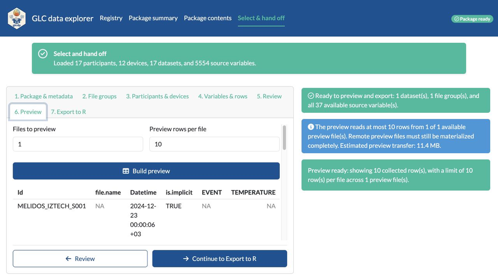

## 6. Export the reproducible R workflow

[figure not shown]

After the download completes, the app names `melidos-iztech-glc-dataset-selection.R` and confirms that it can now be run in R. Continue exploring to adjust the selection, return to the Registry for a different package, or close the browser tab or app.

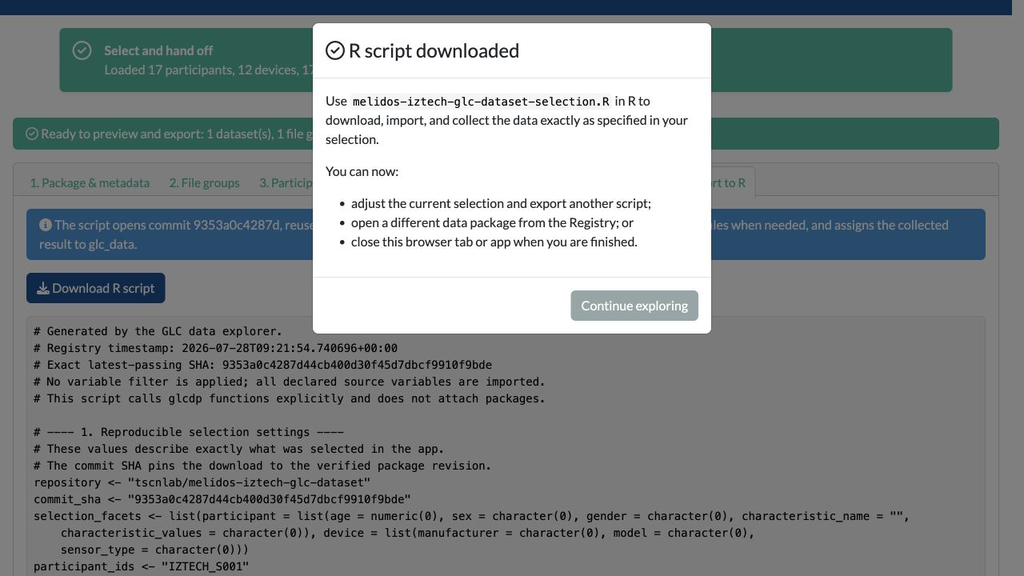

The downloaded script is the durable handoff: save it with the analysis so the selected package commit and either its metadata resources or its measurement files, variables, schema-driven import, and collection behavior remain reviewable and repeatable.